# Lab #6

```python
import pickle
%matplotlib inline
import numpy as np
import matplotlib
import matplotlib.pyplot as plt
import scipy
from scipy import stats
np.random.seed(seed=128)
```

```python
infile2 = open ("qcd_100000_pt_1000_1200.pkl",'rb')
dictQ = pickle.load(infile2)
```

```
5 Sigma value is: 154.0
```

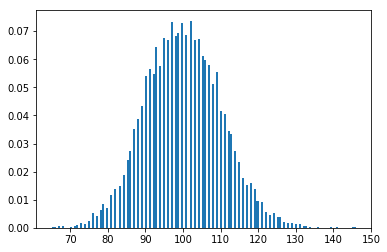

```python
# Prob 1
#xvals = np.linspace(0,200,201)
#fbg = stats.poisson.pmf(xvals,mu=100)
#plt.plot(xvals,fbg);
prob = stats.norm.cdf(5)
sig5 = stats.poisson.ppf(prob,mu=100)
print('5 Sigma value is: ' +str(sig5))

background = stats.poisson.rvs(mu=100,size=10000)
plt.hist(background,bins=150,density=True);
```

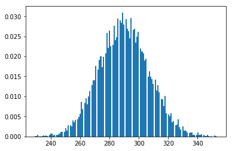

```python
# Prob 2
background = stats.poisson.rvs(mu=290,size=10000)
plt.hist(background,bins=150,density=True);
```

2B. If the distribution was unbiased, then the cdf function of the mean value would give exactly .5, meaning one side is not skewed over the other.

```python
print(stats.poisson.cdf(290,mu=290))
```

```
0.5156109189479057
```

Since this value is larger when calculating the cdf from -infinity to the mean, then it is biased to the left.

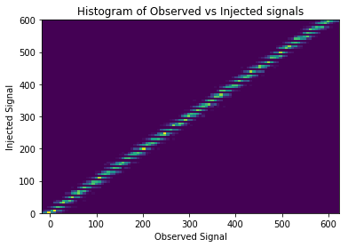

```python
# Prob 3
sig = np.linspace(0,600,61)
inj = []
obs = []
for i in sig:
    inj = np.concatenate((inj,np.zeros(100)+i))
for j in sig:
    backg = stats.poisson.rvs(100,size=100)
    obs = np.concatenate((obs,backg + j -100))
plt.hist2d(obs,inj,100);
plt.xlabel('Observed Signal')
plt.ylabel('Injected Signal')
plt.title('Histogram of Observed vs Injected signals');
```

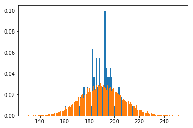

```python
# 3B
# Problem 2 value was 290, so we are looking for the inj=190 histogram
inj_prob2 = obs[1900:2000]
plt.hist(inj_prob2,50,density=True);
plt.hist(background-100,bins=150,density=True);
#print(stats.poisson.cdf(190,mu=190))
#print(stats.poisson.cdf(290,mu=290))
```

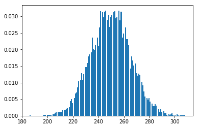

```python
# 3C
# Observed signal of 250
background = stats.poisson.rvs(mu=250,size=10000)
plt.hist(background,bins=150,density=True);
```

This histogram shows what signal was injected into the background when the observed signal was a value of 250. It follows the similar shape of all the other values on the obs. histogram.

```python
# 3D
obs_sig = stats.norm.cdf(1)
print(stats.poisson.ppf(obs_sig,mu = 250))
```

```
266.0
```

Clearly seen that the single sigma uncertainty for the true signal strength is around 16.

3E. To see if it is symmetric, we can take the single sigma value vs then negative sigma value. If the difference between the sigma value and the mean of 250 is the same, then they are symmetric and not biased. If the values do not match, then it is biased.

```python
obs_sig = stats.norm.cdf(1)
print(stats.poisson.ppf(obs_sig,mu = 250))
obs_sig_neg = stats.norm.cdf(-1)
print(stats.poisson.ppf(obs_sig_neg,mu = 250))
```

```
266.0
234.0
```

Both values are 16 away from the mean, meaning a symmetric uncertainty for true signal.

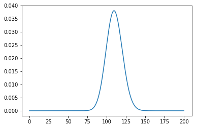

```python
# Prob 4
# Signal = 110, mean = 100
vals = np.linspace(0,200,201)
inj_pdf = stats.poisson.pmf(vals,mu=110)
plt.plot(vals,inj_pdf);
```

Seeing the true signal pdf extend to zero means that there is a legitimately zero change for the value to occur according to the graph.

```python
print(stats.poisson.ppf(.95,mu=110.0))
```

```
128.0
```

So if you observed a candidate signal of 110, then the true signal would be less than 128 for 95% of the time.